# Group Project 2

Intro and EDA

Joshua Carpenter, Yong-Nan Chan, Andy Phillips, and Brandon Fletcher

# Background and Introduction

The World Health Organization (WHO) and United Nations (UN) were interested in factors affecting life expectancy in countries around the world. In 2015 they collected demographic and immunization data from 130 countries.

The purpose of this analysis is to find which factors are correlated with life expectancy and their relationship. We expect to find that having a greater proportion of the population immunized will lead to increased life expectancy and that greater schooling will also be associated with greater life expectancy, although especially in that case we do not believe there is necessarily a causal relationship.

To analyze these hypotheses, we will perform linear regression using `life.expectancy` as our response variable. We will check the assumptions of linear regression and remove or transform variables as necessary. If transformations are necessary, we will use the Box-Cox method and plots of different transformations to help us determine the best one. In order to avoid multicolinearity and over-fitting, we will use several variable selection and shrinkage methods to choose the most appropriate subset of variables to keep in the model. After performing regression, we will examine the model and the hypothesis tests to see which variables are significant and how they affect life expectancy. Finally, we will provide our results along with confidence intervals.

# Methods and Results

The data set we will be using contains measurements, collected in 2015, of 130 different countries. This was collected by the World Health Organization and the United Nations. The data set contains measurements for both developed and developing countries.

The following table displays the variable names in this data set, along with their descriptions.

| Variable | Description |
| --- | --- |
| Status | Country Status (Developed or Developing) |
| Life.expectancy | Average life expectancy in years |
| Adult.Mortality | Probability of dying between 15 and 60 years per 1000 population |
| Hepatitis.B | Immunization coverage among 1-year-olds (%) |
| Measles | Number of reported cases er 1000 population |
| BMI | Average Body Mass Index of entire population |
| Polio | Immunization coverage among 1-year-olds (%) |
| Diphtheria | Immunization coverage among 1-year-olds (%) |
| GDP | Gross Domestic Product per Capita (In USD) |
| Population | Population of the country |
| Schooling | Average number of years of schooling |

## Exploratory Statistics

We start by applying basic summary and exploratory statistics to this data to better understand the data and identify trends.

```r
life_expect <- read_csv("lifeexpect.csv") %>%
  # Change Status into a numeric variable where 1 means
  #   developed and 0 means developing
  mutate(Status = factor(Status),
         # Fix capitalization on Life.expectancy
         Life.Expectancy = Life.expectancy) %>%
  # Remove un-needed columns
  select(Life.Expectancy, Adult.Mortality, Hepatitis.B, BMI, Polio,
         Diphtheria, GDP, Population, Schooling, Status) %>%
  filter(Diphtheria < 100)
life_expect
```

```
## # A tibble: 129 x 10
##    Life.Expectancy Adult.Mortality Hepatitis.B   BMI Polio Diphtheria    GDP
##              <dbl>           <dbl>       <dbl> <dbl> <dbl>      <dbl>  <dbl>
##  1            66.3             198          82  77.6     8         71  1424.
##  2            73.5             133          78  75.2     8         78   494.
##  3            74               125          59  74.7    61         76  4149.
##  4            85                52          97   6.3    97         99  2375.
##  5            82.2             104          55  67      91         90 43316.
##  6            81.1              76          98  61.6    98         98  1923.
##  7            82.4              53          67  59.5    98         98  5585.
##  8            81.7              54          95  69.6    97         97 23819.
##  9            61               102          96  66.5    99         65   188.
## 10            54.9             108          81  66.1    75         59   847.
## # ... with 119 more rows, and 3 more variables: Population <dbl>,
## #   Schooling <dbl>, Status <fct>
```

```r
summary(life_expect)
```

```
##  Life.Expectancy Adult.Mortality  Hepatitis.B         BMI
##  Min.   :51.00   Min.   : 52     Min.   : 6.00   Min.   : 2.50
##  1st Qu.:62.00   1st Qu.:105     1st Qu.:77.00   1st Qu.:23.30
##  Median :66.20   Median :143     Median :91.00   Median :37.90
##  Mean   :67.07   Mean   :169     Mean   :80.55   Mean   :40.37
##  3rd Qu.:71.20   3rd Qu.:215     3rd Qu.:96.00   3rd Qu.:61.20
##  Max.   :85.00   Max.   :484     Max.   :99.00   Max.   :77.60
##      Polio         Diphtheria         GDP             Population
##  Min.   : 6.00   Min.   :46.00   Min.   :   33.68   Min.   :     2966
##  1st Qu.:78.00   1st Qu.:65.00   1st Qu.:  693.90   1st Qu.:   281691
##  Median :91.00   Median :70.00   Median : 2326.16   Median :  1977527
##  Mean   :80.98   Mean   :71.81   Mean   : 6035.12   Mean   : 11720932
##  3rd Qu.:97.00   3rd Qu.:76.00   3rd Qu.: 6432.67   3rd Qu.: 11273661
##  Max.   :99.00   Max.   :99.00   Max.   :56554.39   Max.   :258162113
##    Schooling            Status
##  Min.   : 5.40   Developed : 18
##  1st Qu.:10.80   Developing:111
##  Median :12.70
##  Mean   :12.74
##  3rd Qu.:14.70
##  Max.   :20.40
```

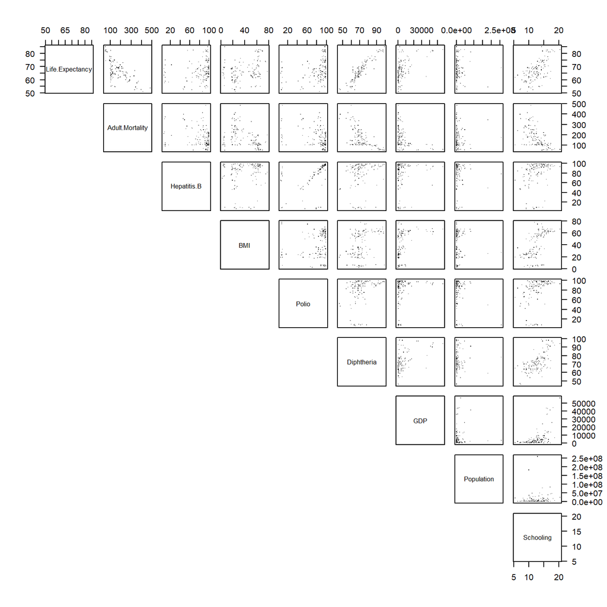

```r
# create data set only with continuous variable
life_expect_cont <- life_expect %>% select(-Status)

### scatterplot matrix (only with continuous)
point_matrix(life_expect_cont)
```

```r
### correlation matrix (only used for continuous variables)
round(cor(life_expect_cont), 2)
```

```
##                 Life.Expectancy Adult.Mortality Hepatitis.B   BMI Polio
## Life.Expectancy            1.00           -0.65        0.20  0.38  0.32
## Adult.Mortality           -0.65            1.00       -0.21 -0.40 -0.36
## Hepatitis.B                0.20           -0.21        1.00  0.14  0.50
## BMI                        0.38           -0.40        0.14  1.00  0.19
## Polio                      0.32           -0.36        0.50  0.19  1.00
## Diphtheria                 0.93           -0.62        0.19  0.37  0.29
## GDP                        0.51           -0.37        0.09  0.39  0.22
## Population                 0.01            0.03       -0.04  0.01 -0.23
## Schooling                  0.64           -0.58        0.30  0.61  0.39
##                 Diphtheria   GDP Population Schooling
## Life.Expectancy       0.93  0.51       0.01      0.64
## Adult.Mortality      -0.62 -0.37       0.03     -0.58
## Hepatitis.B           0.19  0.09      -0.04      0.30
## BMI                   0.37  0.39       0.01      0.61
## Polio                 0.29  0.22      -0.23      0.39
## Diphtheria            1.00  0.51       0.06      0.65
## GDP                   0.51  1.00       0.07      0.57
## Population            0.06  0.07       1.00      0.05
## Schooling             0.65  0.57       0.05      1.00
```

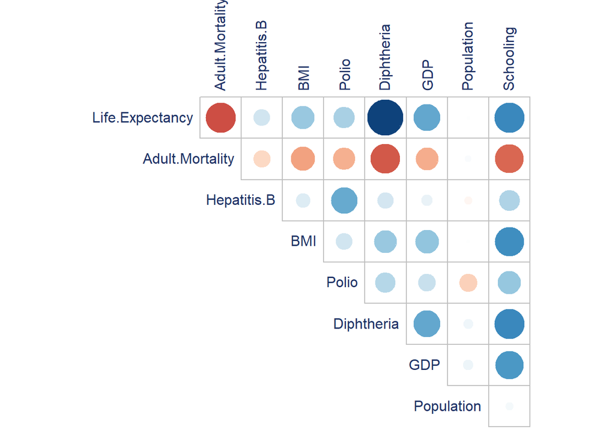

```r
corrplot(cor(life_expect_cont), type = "upper", diag = F,
         tl.col = "#1f3366", cl.pos = "n")
```

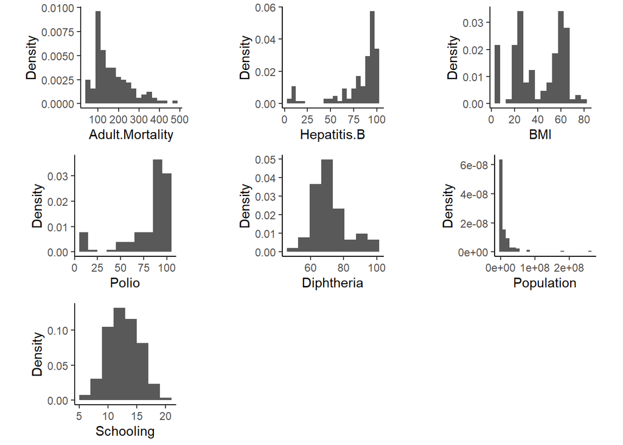

```r
#### Histogram
histLifeExpect <- function(variable, name, width) {
  ggplot(data = life_expect, mapping = aes(x = variable)) +
  geom_histogram(mapping = aes(y = ..density..), binwidth = width) +
  xlab(name) +
  ylab("Density") +
  theme_classic() +
  theme(aspect.ratio = 1)
}
# We remove GDP because the hist is useless and takes a long time to run
to_hist <- life_expect_cont %>%
  select(-c(Life.Expectancy, GDP))
hists <- mapply(histLifeExpect,
       variable = to_hist,
       name = names(to_hist),
       width = c(25, 5, 5, 10, 7, 10000000, 2),
       SIMPLIFY = FALSE)
do.call(grid.arrange, hists)
```

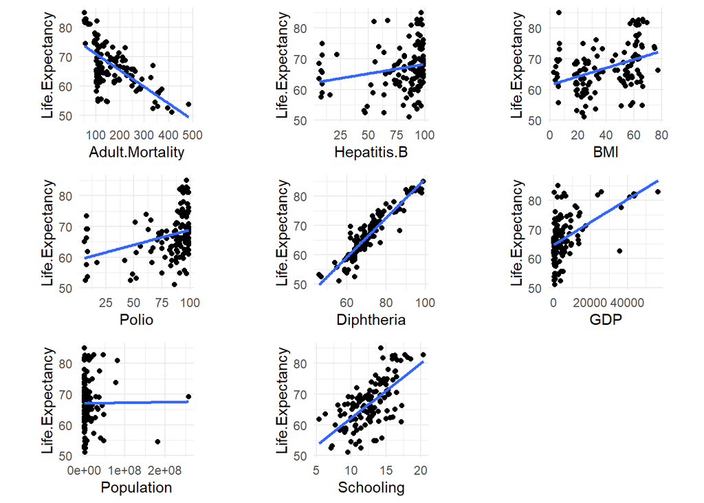

```r
# Individual scatterplots for easier viewing
scatter <- function(data, x_ind, y_ind) {
  x <- pull(data, x_ind)
  y <- pull(data, y_ind)
  ggplot(mapping = aes(x = x, y = y)) +
    geom_point() +
    geom_smooth(method = "lm", se = FALSE) +
    theme_minimal() +
    theme(aspect.ratio = 1) +
    xlab(names(data)[x_ind]) +
    ylab(names(data)[y_ind])
}
splots <- map(2:length(life_expect_cont), scatter, data = life_expect_cont, y_ind = 1)
do.call(grid.arrange, splots)
```

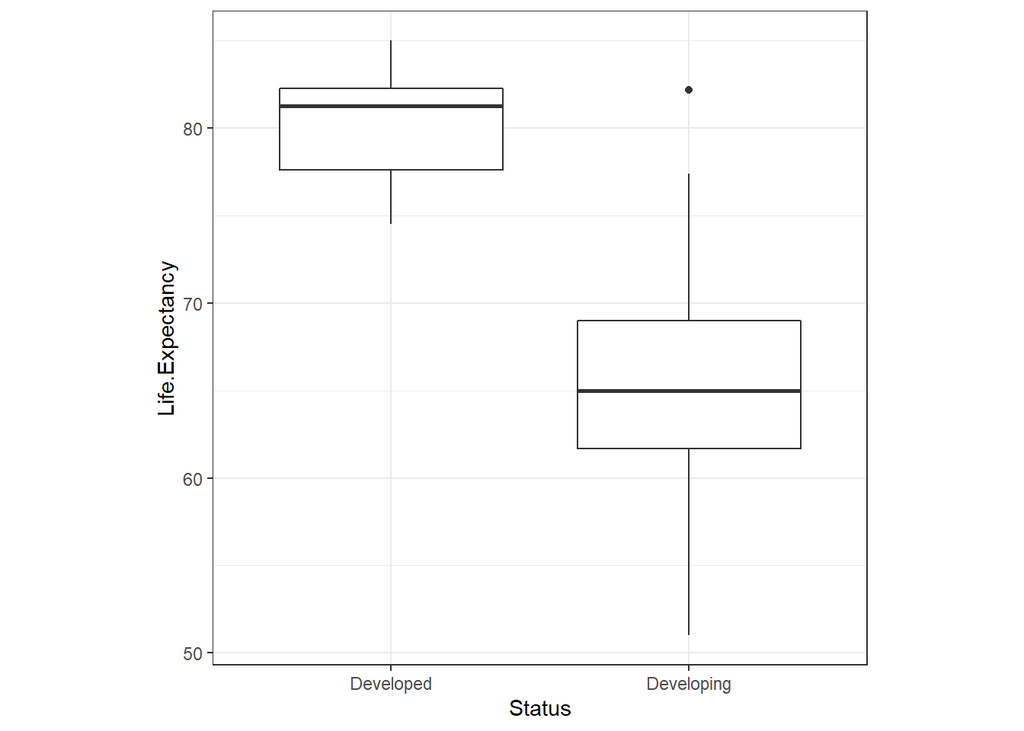

```r
### Box Plot (for categorical: Status)
ggplot(data = life_expect, mapping = aes(x = Status, y = Life.Expectancy)) +
  geom_boxplot() +
  theme_bw() +
  theme(aspect.ratio = 1)
```

## Variable Selection

```r
#create new variable and put Life.Expectancy last
life_expect_var <- life_expect %>%
  select(Adult.Mortality : Status, Life.Expectancy) %>%
  as.data.frame()
head(life_expect_var)

life_expect_var_lm <- lm(Life.Expectancy ~ ., life_expect_var)
summary(life_expect_var_lm)

#BEST SUBSETS
life_best_subsets_bic <- bestglm(life_expect_var, IC = "BIC", method = "exhaustive")

life_best_subsets_bic$BestModels
summary(life_best_subsets_bic$BestModel)

# BACKWARD
life_backward_bic <- bestglm(life_expect_var, IC = "BIC", method = "backward", t = 100)
summary(life_backward_bic$BestModel)

# SEQUENTIAL
life_seqrep_bic <- bestglm(life_expect_var, IC = "BIC", method = "seqrep", t = 100)
summary(life_seqrep_bic$BestModel)


# Note: had trouble with the data turning into a matrix here
life_expect_var_x <- as.matrix(life_expect_var[,1:7])
life_expect_var_y <- life_expect_var[,8]

#LASSO
life_expect_var_lasso_cv <- cv.glmnet(x = life_expect_var_x,
                              y = life_expect_var_y,
                              type.measure = "mse",
                              alpha = 1)
life_expect_var_lasso_cv$lambda.min
life_expect_var_lasso_cv$lambda.1se

coef(life_expect_var_lasso_cv, s = "lambda.min")
coef(life_expect_var_lasso_cv, s = "lambda.1se")

#ELASTIC NET
life_expect_var_elastic_cv <- cv.glmnet(x = life_expect_var_x,
                              y = life_expect_var_y,
                              type.measure = "mse",
                              alpha = 0.5)
life_expect_var_elastic_cv$lambda.min
life_expect_var_elastic_cv$lambda.1se

coef(life_expect_var_elastic_cv, s = "lambda.min")
coef(life_expect_var_elastic_cv, s = "lambda.1se")
```

| Variable | Best Subset | Backward | Sequential Replacement | LASSO | Elastic Net |
| --- | --- | --- | --- | --- | --- |
| Adult.Mortality | X | X | X | X | X |
| Hepatitis.B |  |  |  | X | X |
| BMI |  |  |  | X | X |
| Polio |  |  |  | X | X |
| Diphtheria | X | X | X | X | X |
| GDP |  |  |  | X | X |
| Population |  |  |  |  |  |
| Schooling |  |  |  |  |  |
| Status |  |  | X |  |  |

Given the results from all of the variable selection procedures, shown in the table above, we choose to keep Adult.Mortality and Diphtheria.

## Initial Linear Model

Next, we will run an initial linear model and take a look at the residuals to see what transformations might need to be done.

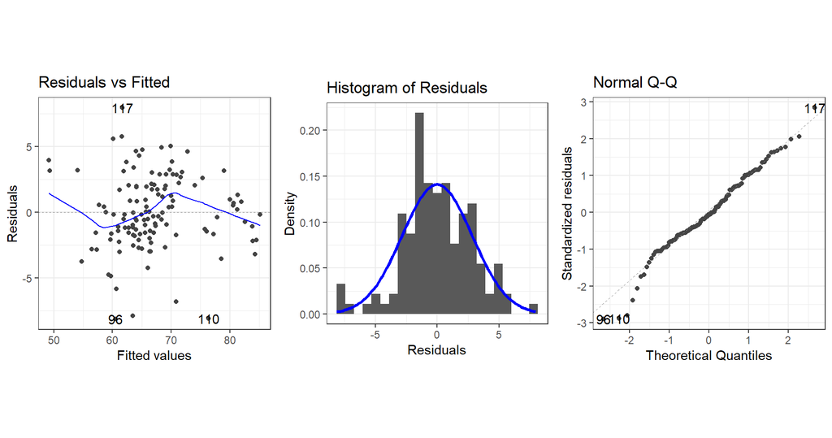

```r
init_model <- lm(Life.Expectancy ~ Adult.Mortality + Diphtheria, data = life_expect)
rvf <- resid_vs_fitted(init_model)@plots[[1]] +
  theme_bw() + theme(aspect.ratio = 1)
hist <- jcreg_hist(init_model) +
  theme_bw() + theme(aspect.ratio = 1) +
  ggtitle("Histogram of Residuals")
qq <- jcreg_qq(init_model)@plots[[1]]
grid.arrange(rvf, hist, qq, ncol = 3)
```

```r
shapiro.test(init_model$residuals)
```

```
##
##  Shapiro-Wilk normality test
##
## data:  init_model$residuals
## W = 0.98234, p-value = 0.09175
```

The residuals are fairly normal, with some outliers at the lower tail. There does appear to be a slight cone shape to the residuals, which could be a problem. Based on these graphs we will attempt a transformation on the response.

## Check if we need to include an interaction

```r
interaction_model <- lm(Life.Expectancy ~ Adult.Mortality + Diphtheria + Adult.Mortality:Diphtheria, data = life_expect)
anova(init_model, interaction_model)
```

```
## Analysis of Variance Table
##
## Model 1: Life.Expectancy ~ Adult.Mortality + Diphtheria
## Model 2: Life.Expectancy ~ Adult.Mortality + Diphtheria + Adult.Mortality:Diphtheria
##   Res.Df    RSS Df Sum of Sq      F Pr(>F)
## 1    126 1027.0
## 2    125 1026.6  1   0.38092 0.0464 0.8298
```

The p-value for the difference between models is highly insignificant, so we will not include an interaction.

## Transformations

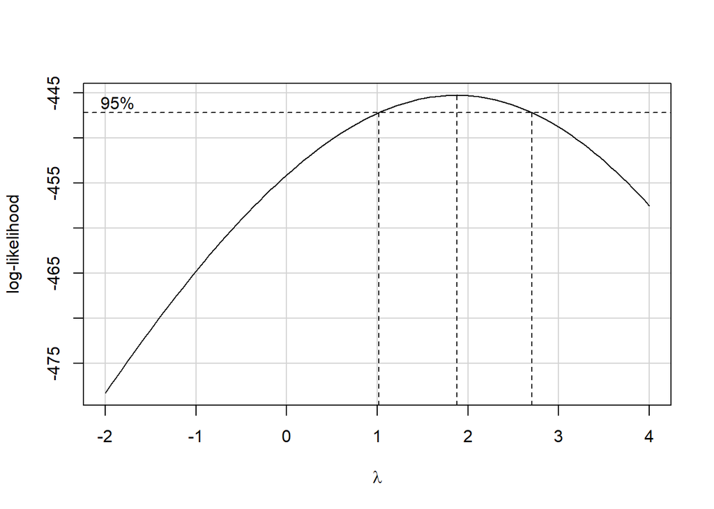

```r
# Apply boxCox to give us a starting point
boxCox(init_model, lambda = seq(-2, 4, 1/10))
```

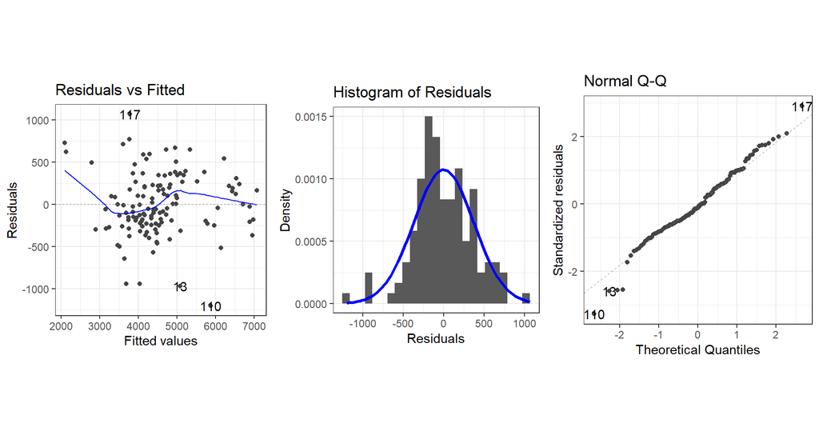

```r
# Squared transformation
life_expect_sq <- life_expect %>%
  mutate(Life.Expectancy = Life.Expectancy^2)
sq_model <- lm(Life.Expectancy ~ Adult.Mortality + Diphtheria, data = life_expect_sq)
rvf <- resid_vs_fitted(sq_model)@plots[[1]] +
  theme_bw() + theme(aspect.ratio = 1)
hist <- jcreg_hist(sq_model) +
  theme_bw() + theme(aspect.ratio = 1) +
  ggtitle("Histogram of Residuals")
qq <- jcreg_qq(sq_model)@plots[[1]]
grid.arrange(rvf, hist, qq, ncol = 3)
```

```r
shapiro.test(sq_model$residuals)
```

```
##
##  Shapiro-Wilk normality test
##
## data:  sq_model$residuals
## W = 0.98219, p-value = 0.08867
```

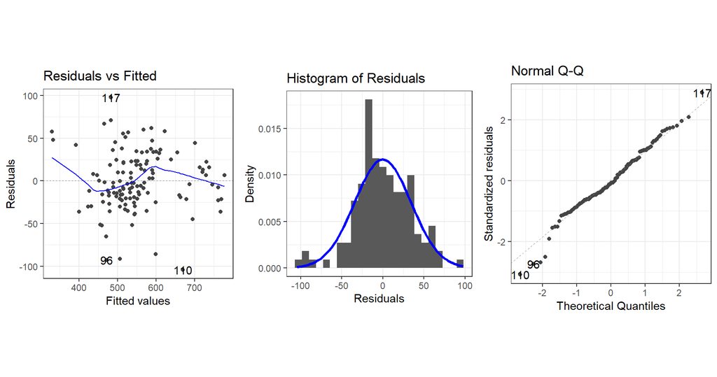

```r
# Power of 1.5 transformation
life_expect_15 <- life_expect %>%
  mutate(Life.Expectancy = Life.Expectancy^1.5)
model_15 <- lm(Life.Expectancy ~ Adult.Mortality + Diphtheria, data = life_expect_15)
rvf <- resid_vs_fitted(model_15)@plots[[1]] +
  theme_bw() + theme(aspect.ratio = 1)
hist <- jcreg_hist(model_15) +
  theme_bw() + theme(aspect.ratio = 1) +
  ggtitle("Histogram of Residuals")
qq <- jcreg_qq(model_15)@plots[[1]]
grid.arrange(rvf, hist, qq, ncol = 3)
```

```r
shapiro.test(model_15$residuals)
```

```
##
##  Shapiro-Wilk normality test
##
## data:  model_15$residuals
## W = 0.98311, p-value = 0.1094
```

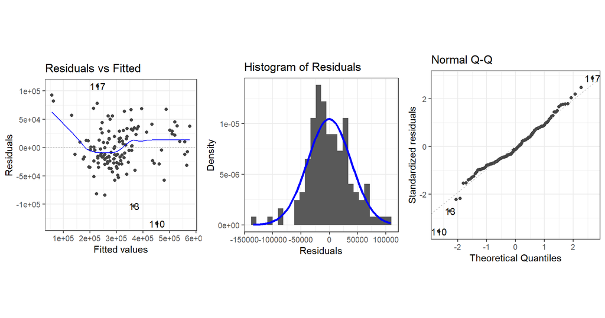

```r
# Cubed transformation
life_expect_cu <- life_expect %>%
  mutate(Life.Expectancy = Life.Expectancy^3)
cu_model <- lm(Life.Expectancy ~ Adult.Mortality + Diphtheria, data = life_expect_cu)
rvf <- resid_vs_fitted(cu_model)@plots[[1]] +
  theme_bw() + theme(aspect.ratio = 1)
hist <- jcreg_hist(cu_model) +
  theme_bw() + theme(aspect.ratio = 1) +
  ggtitle("Histogram of Residuals")
qq <- jcreg_qq(cu_model)@plots[[1]]
grid.arrange(rvf, hist, qq, ncol = 3)
```

```r
shapiro.test(cu_model$residuals)
```

```
##
##  Shapiro-Wilk normality test
##
## data:  cu_model$residuals
## W = 0.98028, p-value = 0.05721
```

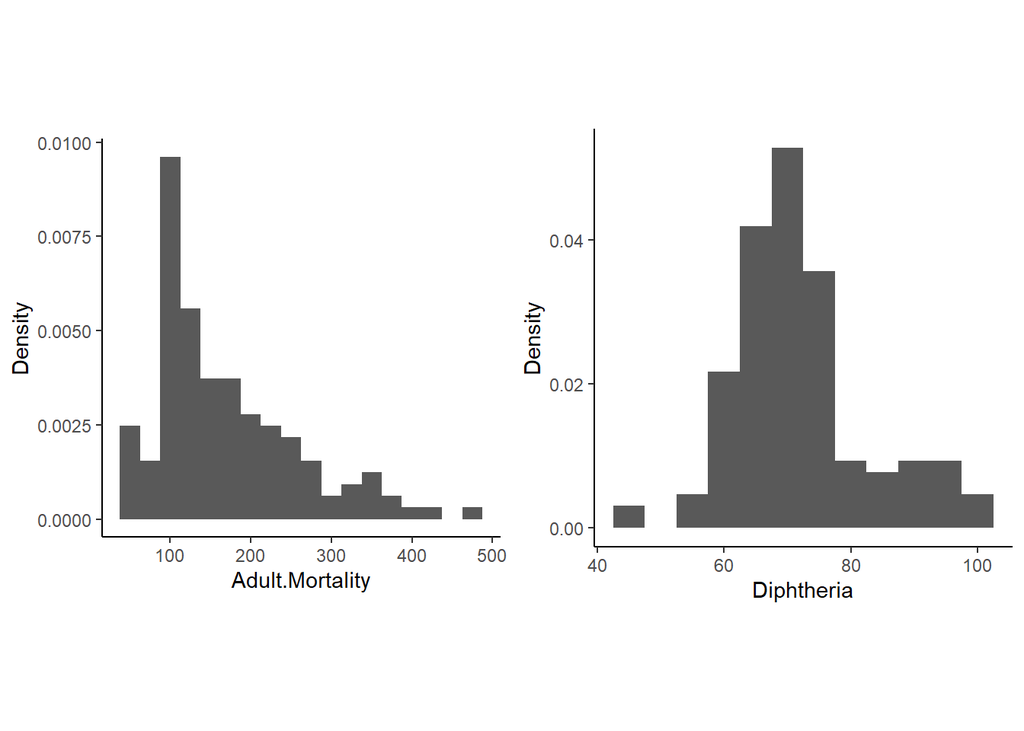

```r
life_expect_sq <- life_expect_sq %>%
  select(Life.Expectancy, Adult.Mortality, Diphtheria)
to_hist <- life_expect_sq %>%
  select(-Life.Expectancy)
hists <- mapply(histLifeExpect,
       variable = to_hist,
       name = names(to_hist),
       width = c(25, 5),
       SIMPLIFY = FALSE)
hists[["ncol"]] <- 2
do.call(grid.arrange, hists)
```

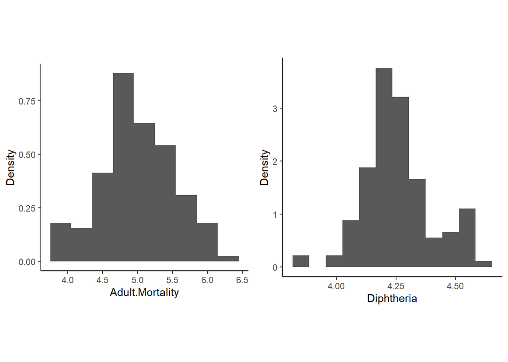

```r
# Log transformation
life_expect_t <- life_expect_sq %>%
  mutate(Adult.Mortality = log(Adult.Mortality),
        Diphtheria = log(Diphtheria))
to_hist <- life_expect_t %>%
  select(-Life.Expectancy)
hists <- mapply(histLifeExpect,
       variable = to_hist,
       name = names(to_hist),
       width = c(0.3, 0.07),
       SIMPLIFY = FALSE)
hists[["ncol"]] <- 2
do.call(grid.arrange, hists)
```

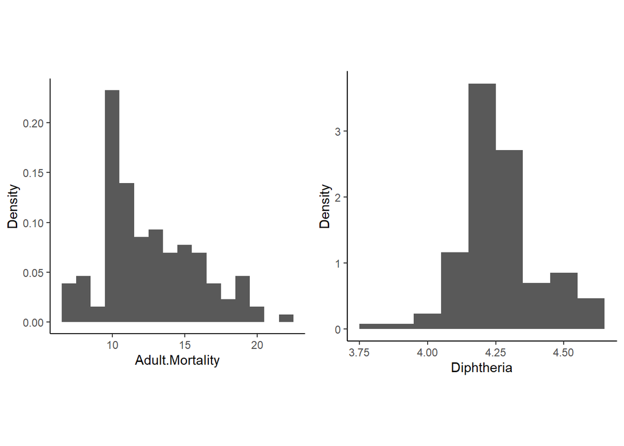

```r
# Sqrt transformation
life_expect_t <- life_expect_sq %>%
  mutate(Adult.Mortality = sqrt(Adult.Mortality),
        Diphtheria = log(Diphtheria))
to_hist <- life_expect_t %>%
  select(-Life.Expectancy)
hists <- mapply(histLifeExpect,
       variable = to_hist,
       name = names(to_hist),
       width = c(1, 0.1),
       SIMPLIFY = FALSE)
hists[["ncol"]] <- 2
do.call(grid.arrange, hists)
```

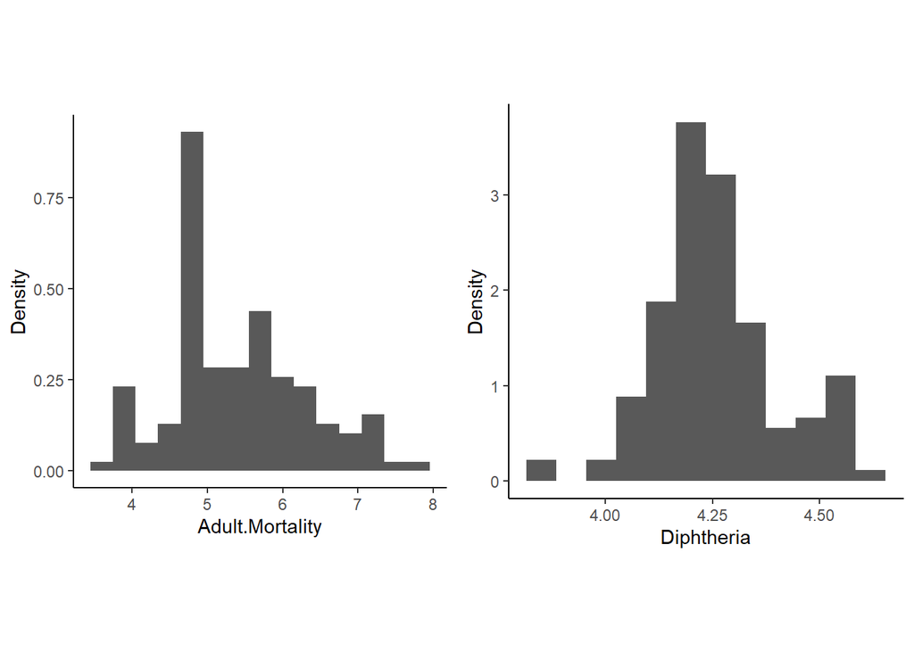

```r
# Cbrt transformation
life_expect_t <- life_expect_sq %>%
  mutate(Adult.Mortality = Adult.Mortality^(1/3),
        Diphtheria = log(Diphtheria))
to_hist <- life_expect_t %>%
  select(-Life.Expectancy)
hists <- mapply(histLifeExpect,
       variable = to_hist,
       name = names(to_hist),
       width = c(0.3, 0.07),
       SIMPLIFY = FALSE)
hists[["ncol"]] <- 2
do.call(grid.arrange, hists)
```

Adult Mortality was skewed, so we attempted a transformation. Clearly the log transform looks more normal than the others. For Diphtheria, we will stick to the original data.

```r
life_expect_t <- life_expect_sq %>%
  mutate(Adult.Mortality = log(Adult.Mortality))
```

## Final Linear Model

```r
life_expect_lm <- lm(Life.Expectancy ~ ., data = life_expect_t)
summary(life_expect_lm)
```

```
##
## Call:
## lm(formula = Life.Expectancy ~ ., data = life_expect_t)
##
## Residuals:
##      Min       1Q   Median       3Q      Max
## -1158.21  -235.34   -47.11   237.97  1057.41
##
## Coefficients:
##                 Estimate Std. Error t value Pr(>|t|)
## (Intercept)     -567.788    713.102  -0.796   0.4274
## Adult.Mortality -210.566     91.357  -2.305   0.0228 *
## Diphtheria        86.040      4.372  19.679   <2e-16 ***
## ---
## Signif. codes:  0 '***' 0.001 '**' 0.01 '*' 0.05 '.' 0.1 ' ' 1
##
## Residual standard error: 375.4 on 126 degrees of freedom
## Multiple R-squared:  0.8755, Adjusted R-squared:  0.8735
## F-statistic: 442.9 on 2 and 126 DF,  p-value: < 2.2e-16
```

Our final fitted model is:

$$(\widehat{\text{Life.Expectancy}}_i)^2=-567.8-210.6\cdot\log(\text{Adult.Mortality}_i)+86.0\cdot\text{Diphtheria}_i$$

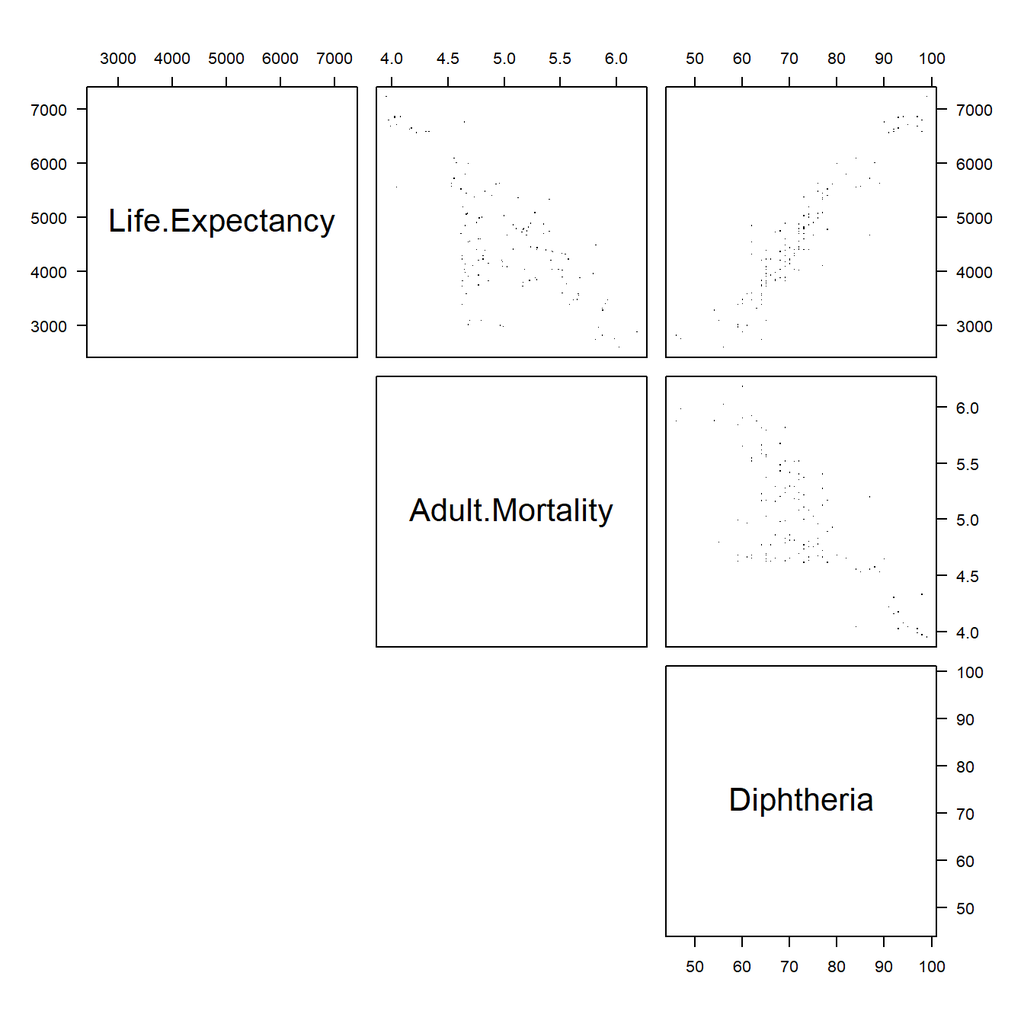

```r
point_matrix(life_expect_t)
```

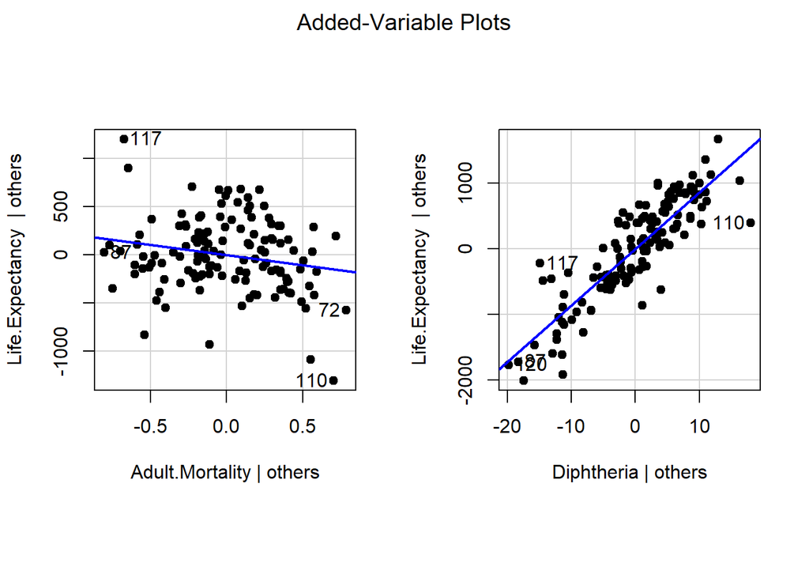

```r
jcreg_av(life_expect_lm)
```

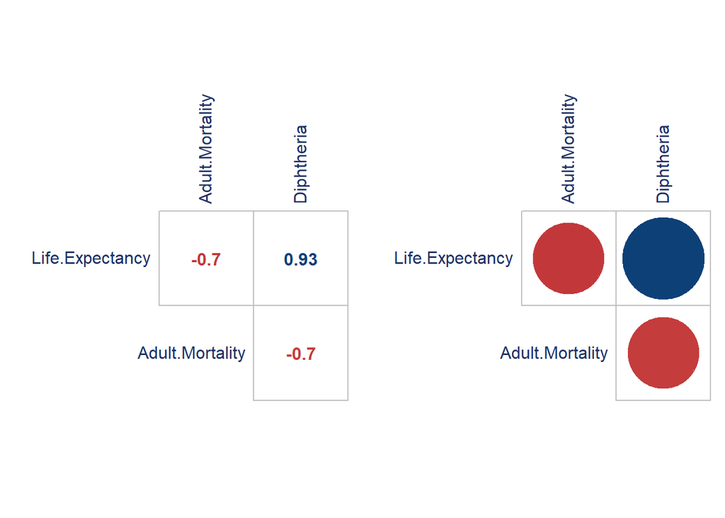

```r
cor_graphic(life_expect_t, title = FALSE)
```

```r
vif(life_expect_lm)
```

```
## Adult.Mortality      Diphtheria
##        1.943224        1.943224
```

The linearity assumption is met. The partial regression plots appear to be linear. There is a strong negative correlation between Adult.Mortality and the Percentage of 1 year olds vaccinated against Diptheria. However, this correlation is below the multicollinearity cutoff of 0.8. The average VIF is 1.94 which is above the cutoff of 1. However we feel that the multicollinearity assumption is met. The independence assumption is met, the data was collected randomly.

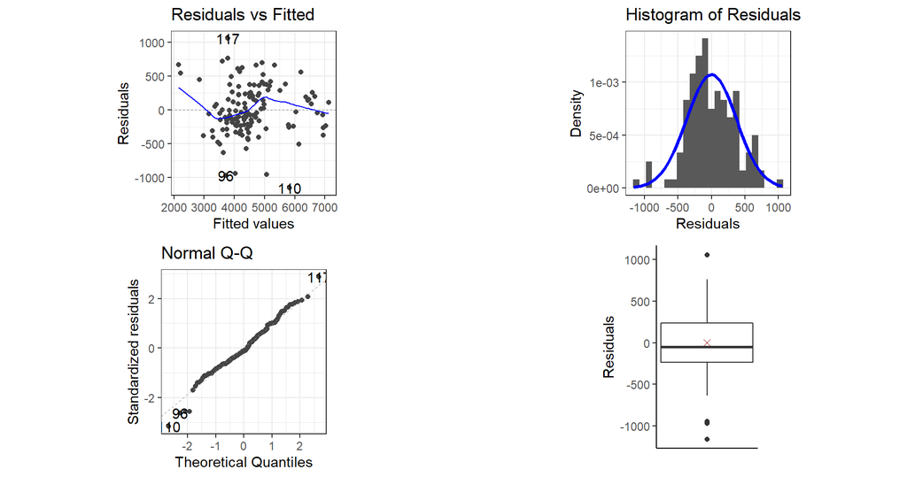

```r
# Plot residuals
rvf <- resid_vs_fitted(life_expect_lm)@plots[[1]] +
  theme_bw() + theme(aspect.ratio = 1)
hist <- jcreg_hist(life_expect_lm) +
  theme_bw() + theme(aspect.ratio = 1) +
  ggtitle("Histogram of Residuals")
qq <- jcreg_qq(life_expect_lm)@plots[[1]]
boxp <- jcreg_boxplot(life_expect_lm)
grid.arrange(rvf, hist, qq, boxp, ncol = 2)
```

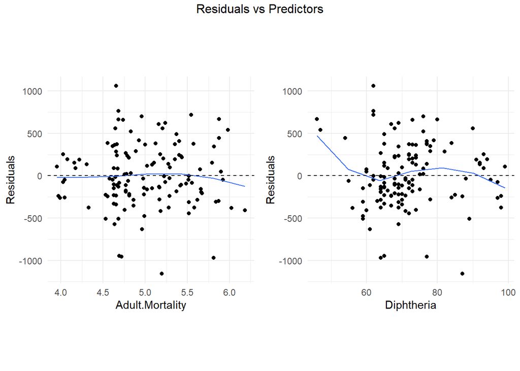

```r
resid_vs_pred(life_expect_lm)
```

```r
shapiro.test(life_expect_lm$residuals)
```

```
##
##  Shapiro-Wilk normality test
##
## data:  life_expect_lm$residuals
## W = 0.98361, p-value = 0.1226
```

The Normality assumption is met. The residuals appear to be fairly normally distributed around 0. The p-value of the shapiro-wilk test is greater than 0.05 so we can say that the data is normally distributed.

There does not appear to be any distinctive cone shape to the data in the residual vs. fitted value plot so we can assume that the homoskedastic assumption is met.

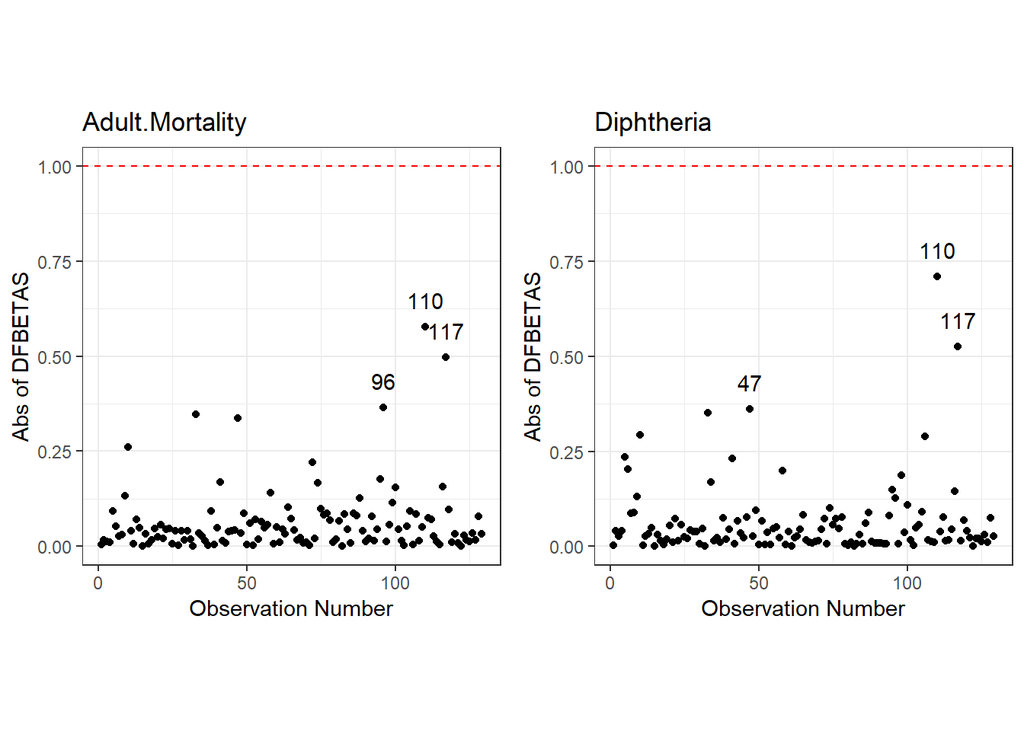

```r
# Check for influential points
jcreg_dfbetas(life_expect_lm)
```

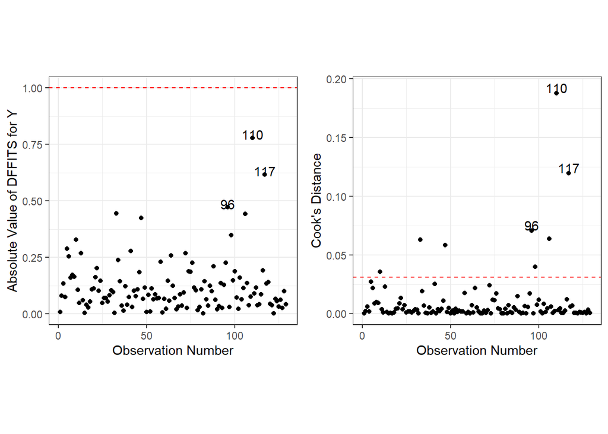

```r
dffits <- jcreg_dffits(life_expect_lm)
cooksd <- jcreg_cooksd(life_expect_lm)
grid.arrange(dffits, cooksd, ncol = 2)
```

There are a few points (110 and 117) that show up in a few of the plots but these are not too far out from the other points so the assumption of no influential points is met

## Model Assessment

```r
# <... code here...>
# Include things like: slopes, hypothesis tests, confidence intervals,
# prediction intervals, etc.
# If you have an interaction, code to compute the effect of one of the
# interaction variables on the response, etc.

confint(life_expect_lm, level = 0.95)
```

```
##                       2.5 %    97.5 %
## (Intercept)     -1978.99559 843.42037
## Adult.Mortality  -391.35829 -29.77403
## Diphtheria         77.38813  94.69263
```

```r
#confidence interval with mean adult mortality and mean diphtheria
predict(life_expect_lm,
        newdata = data.frame(Adult.Mortality = log(169),
                             Diphtheria = 72),
        interval = "confidence",
        level = 0.95)
```

```
##        fit      lwr      upr
## 1 4546.937 4477.218 4616.655
```

```r
#prediction interval with mean adult mortality and mean diphtheria
predict(life_expect_lm,
        newdata = data.frame(Adult.Mortality = log(169),
                             Diphtheria = 72),
        interval = "prediction",
        level = 0.95)
```

```
##        fit      lwr     upr
## 1 4546.937 3800.733 5293.14
```

```r
#confidence interval with mean adult mortality and everyone vaccinated against Diphtheria
predict(life_expect_lm,
        newdata = data.frame(Adult.Mortality = log(169),
                             Diphtheria = 99),
        interval = "confidence",
        level = 0.95)
```

```
##        fit      lwr      upr
## 1 6870.027 6609.901 7130.152
```

```r
#confidence interval with mean adult mortality and no one vaccinated against Diphtheria
predict(life_expect_lm,
        newdata = data.frame(Adult.Mortality = log(169),
                             Diphtheria = 46),
        interval = "confidence",
        level = 0.95)
```

```
##        fit      lwr      upr
## 1 2309.887 2091.847 2527.926
```

Confidence and Prediction intervals for specific values. We are 95% that the average life expectancy in a country with an average adult mortality of 169 per 1000 and a diphtheria vaccination rate of 72% is between 66.912 years and 67.946 years

We are 95% confident that the life expectancy of a country with an average adult mortality of 169 per 1000 and a diphtheria vaccination rate of 72% will be between 61.650 years and 72.754 years.

We are 95% confident that the average life expectancy in a country with an average adult mortality of 169 per 1000 and a diphtheria vaccination rate of 99% will be between 81.301 years and 84.440 years.

We are 95% confident that the average life expectancy in a country with an average adult mortality of 169 per 1000 and a diphtheria vaccination rate of 46% will be between 45.737 years and 50.278 years.

## Interpretations

```r
# <...more code here...>
# Include things like: R2, RMSE, MAE, etc.
summary(life_expect_lm)
```

```
##
## Call:
## lm(formula = Life.Expectancy ~ ., data = life_expect_t)
##
## Residuals:
##      Min       1Q   Median       3Q      Max
## -1158.21  -235.34   -47.11   237.97  1057.41
##
## Coefficients:
##                 Estimate Std. Error t value Pr(>|t|)
## (Intercept)     -567.788    713.102  -0.796   0.4274
## Adult.Mortality -210.566     91.357  -2.305   0.0228 *
## Diphtheria        86.040      4.372  19.679   <2e-16 ***
## ---
## Signif. codes:  0 '***' 0.001 '**' 0.01 '*' 0.05 '.' 0.1 ' ' 1
##
## Residual standard error: 375.4 on 126 degrees of freedom
## Multiple R-squared:  0.8755, Adjusted R-squared:  0.8735
## F-statistic: 442.9 on 2 and 126 DF,  p-value: < 2.2e-16
```

```r
# I totally blanked how to do the RMSE and MAE

# MSE
anova <- aov(life_expect_lm)  # get ANOVA components
life_expect_anova <- summary(anova)[[1]]  # save data in a usable form
(mse = life_expect_anova["Residuals", "Sum Sq"] /
    life_expect_anova["Residuals", "Df"])
```

```
## [1] 140937.9
```

```r
# RMSE
(sqrt(mse))
```

```
## [1] 375.4169
```

```r
# MAE
life_expect_t$fitted_life.expectancy <- life_expect_lm$fitted.values
sum(abs(life_expect_t$Life.Expectancy - life_expect_t$fitted_life.expectancy) /
  life_expect_lm$df.residual)
```

```
## [1] 298.3769
```

It turns out that the model fits the data pretty well. An $R^2$ of 87.5% is rather high, and indicates that the variables we chose have done a good job describing the model. The RMSE is 375.4. Since we transform the response variable to a square (the scale is transforms to the scale about 3000 to 7000), the RMSE is relatively low comparing to the scale. In other words, the average error performed by the model is small. The MAE also have a relative small number comparing to the scale of the transformed model, which also indicated that the average absolute difference between the outcome and the prediction is small.

### Summary and Conclusions

Life expectancy is one of the most frequently used metrics to determine health status among countries. It is also a good indicator of the development within countries. We conducted an analysis to find out which variables significantly affected life expectancy in 130 different countries. After fitting a multiple linear regression model, we found that the percent of infants immunized against diphtheria has a significant positive impact on life expectancy (the higher the immunization rate the higher the life expectancy). We also found that adult mortality had a negative impact on life expectancy.